### **Executive Summary**: East Asian Social Survey (EASS), Cross-National Survey Data: Network Social Capital in East Asia, 2012"

In the exploratory data analysis of the 2012 East Asian Social Survey (EASS), I explored the simlarity and differences between four East Asian countries: China, Japan, Korea, and Taiwan. My goal of the analysis was to discover nuanced differences among the four countries by exploring the basic demographic indicators and social capital variables the 2012 survey measured. Here are the highlightable findings from the analysis:

### Perceived social hierarchy

Individuals were asked to rate their social hierarchy on a 10-point scale. When this data was plotted by country level, it did not reveal much considerable differences. However, more interesting trends were found by plotting this data against other demographic factors such as age group and education level.

#### Perceived social hierarchy by age group

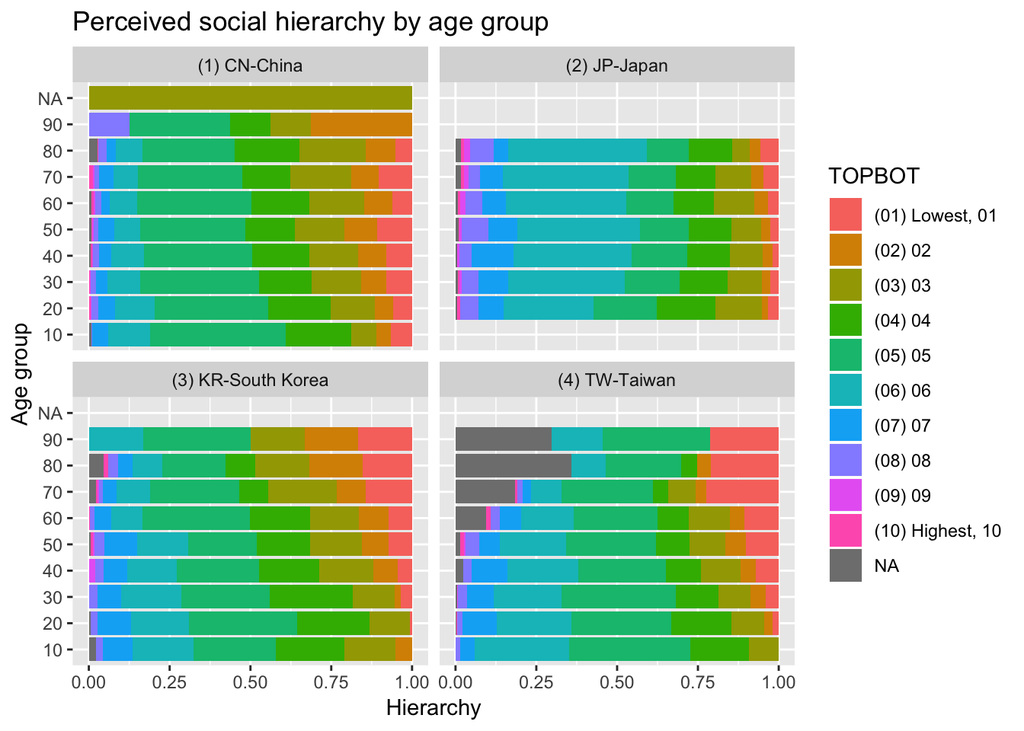

While most countries experience the “worsening” of perceived social hierarchy as you observe bottom to top across the y axis (younger to older), Japan showcased the opposite trend, with greater share of people rating their social hierarchy to be 6 or higher as you went up the y-axis.

#### Perceived social hierarchy by education level

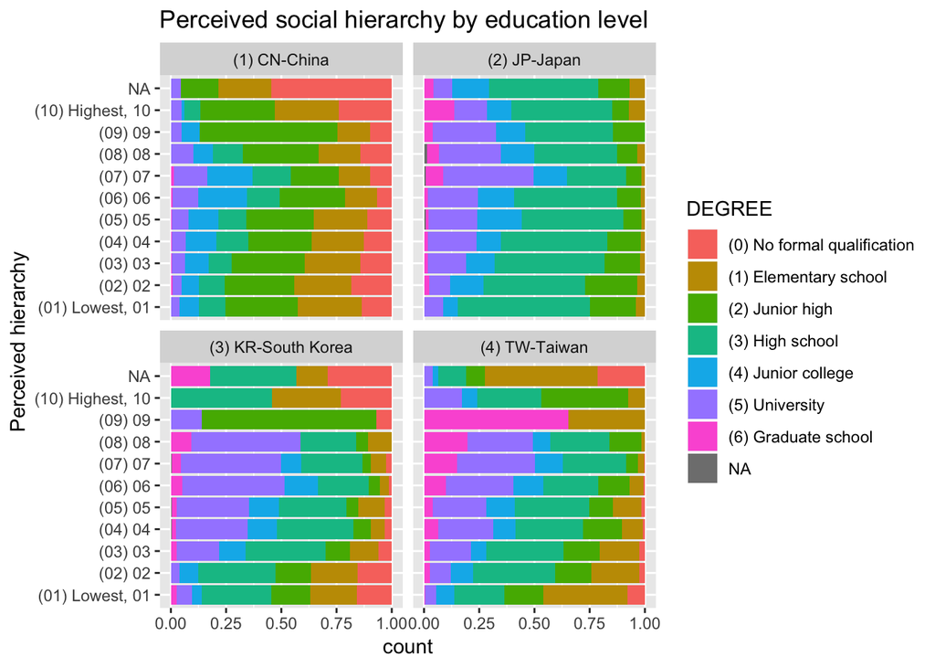

The first key thing that should be pointed out here is how the four countries differ in their predominant education level; note **Korea**’s big proportion of percentage of university graduates, **China**’s junior high school graduates, and **Japan**’s high school diploma holders.  
Overall, though university + graduate school degree did increase higher as you went up the y axis (lower to higher perceived hierarchy), this trend generally ended at around the score of 7 to 8. The highest social hierarchyof the self (of score 10) was perceived, surprisingly, mostly by those with high school diplomas (middle school in the case of China and Taiwan). It is interesting to conclude that education level did not ensure the highest perceived social hierarchy.

### Psychological help

The survey participants were asked who they turn to when seeking for emotional/psychological problems. Similar to perceived social hierarchy, there were no significant differences among the four countries when the responses were plotted on the country level.

#### Psychological help by age group

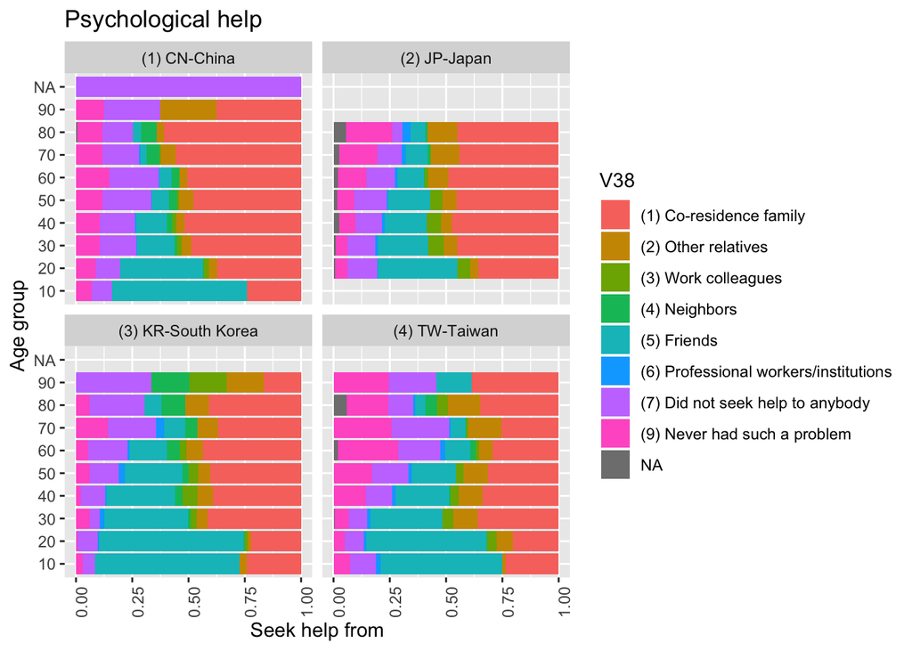

However, when this information was plotted against age group, a clear association with age and source of help was found. The dichotomy between the age of people seeing for help from friends vs. family is quite visually striking on the plot above. While an overwhelming portion of younger respondents reported turning to friends for psychological help, this portion gradually drops as you go up the y-axis, as the portion relying on co-residence family member gradually increases, until it reaches the most popular choice among older groups.  
This plot illustrates one of the many cases in which the perceivable similarity among these four countries is were driven not necessarily due to the four countries’ cultural differences, but mainly due to the differences experienced generationally, on the basis of gender (and the soceital norms that affect gender), and/or different markers of status.